# Activities - Solution

### Activity 3

**a) Hypothesis tests for two populations:**

- a.1) Choose the best way to import file “feeders_select_exercise.csv” and save it to an object named feeders.

This file contains measurements (OD_avg and pH) taken from a sucrose solution present in 10 different bird feeders. Measurements were made at day 1 and at day 7 after changing the solution. The purpose will be to see differences between both days

```r
feeders <- read.csv("data/feeders_select_exercise.csv")
```

- a.2) Check the str() to confirm that, al least, both numeric variables (OD_avg and pH) are in fact numeric and not factors. DurGrowth should be a factor.

```r
# change DurGROWTH to a factor
feeders$DurGROWTH <- factor(feeders$DurGROWTH)

levels(feeders$DurGROWTH)
```

```
## [1] "1" "7"
```

- a.3) Calculate the mean, sd and median of variables pH and OD_avg for day 1 and day 7.

```r
by(feeders$OD_avg, feeders$DurGROWTH, mean, na.rm=TRUE)
```

```
## feeders$DurGROWTH: 1
## [1] 0.038025
## --------------------------------------------------------
## feeders$DurGROWTH: 7
## [1] 0.042325
```

```r
by(feeders$OD_avg, feeders$DurGROWTH, median, na.rm=TRUE)
```

```
## feeders$DurGROWTH: 1
## [1] 0.03865
## --------------------------------------------------------
## feeders$DurGROWTH: 7
## [1] 0.042
```

```r
by(feeders$OD_avg, feeders$DurGROWTH, sd, na.rm=TRUE)
```

```
## feeders$DurGROWTH: 1
## [1] 0.002459251
## --------------------------------------------------------
## feeders$DurGROWTH: 7
## [1] 0.002273427
```

```r
by(feeders$pH, feeders$DurGROWTH, mean, na.rm=TRUE)
```

```
## feeders$DurGROWTH: 1
## [1] 4.4401
## --------------------------------------------------------
## feeders$DurGROWTH: 7
## [1] 3.6765
```

```r
by(feeders$pH, feeders$DurGROWTH, median, na.rm=TRUE)
```

```
## feeders$DurGROWTH: 1
## [1] 4.2535
## --------------------------------------------------------
## feeders$DurGROWTH: 7
## [1] 3.671
```

```r
by(feeders$pH, feeders$DurGROWTH, sd, na.rm=TRUE)
```

```
## feeders$DurGROWTH: 1
## [1] 0.4024783
## --------------------------------------------------------
## feeders$DurGROWTH: 7
## [1] 0.3874203
```

- a.4) How many measurement (n) were taken in day 1 and in day 7?

```r
summary(feeders)
```

```
##        X              TRIAL             DATE      TIME      SITE
##  Min.   :  1.00   Min.   :1.00   03/jul/17:4   06:00:4   Glide:20
##  1st Qu.:  5.75   1st Qu.:1.75   11/jul/17:3   06:15:7
##  Median : 10.50   Median :2.00   13/jun/17:3   06:40:2
##  Mean   : 22.25   Mean   :2.10   17/jul/17:4   07:10:4
##  3rd Qu.: 15.25   3rd Qu.:3.00   19/jun/17:2   07:20:3
##  Max.   :110.00   Max.   :3.00   27/jun/17:4
##  DurGROWTH     FEED.N     TREATMENT OBSERVER    FEED.WT
##  1:10      Min.   : 1.0   cage:20   CGL :5   Min.   :1305
##  7:10      1st Qu.: 3.0             TH  :8   1st Qu.:1460
##            Median : 5.5             NA's:7   Median :1534
##            Mean   : 5.5                      Mean   :1517
##            3rd Qu.: 8.0                      3rd Qu.:1605
##            Max.   :10.0                      Max.   :1633
##    FEED.TEMP           pH             OD_1              OD_2
##  Min.   :52.70   Min.   :3.011   Min.   :0.03360   Min.   :0.03410
##  1st Qu.:57.50   1st Qu.:3.712   1st Qu.:0.03875   1st Qu.:0.03760
##  Median :60.35   Median :4.251   Median :0.04035   Median :0.03960
##  Mean   :60.62   Mean   :4.058   Mean   :0.04038   Mean   :0.03997
##  3rd Qu.:64.10   3rd Qu.:4.253   3rd Qu.:0.04202   3rd Qu.:0.04280
##  Max.   :71.10   Max.   :5.530   Max.   :0.04600   Max.   :0.04660
##      OD_avg
##  Min.   :0.03385
##  1st Qu.:0.03848
##  Median :0.03997
##  Mean   :0.04018
##  3rd Qu.:0.04229
##  Max.   :0.04620
```

```r
# 10 measurements for each day
```

- a.5) Is pH data for day 7 and day 1 normally distributed? What about OD_avg? Which type of tests would you use for each variable.

```r
# for OD_avg
shapiro.test(feeders[feeders$DurGROWTH == "7", "OD_avg"])
```

```
##
##  Shapiro-Wilk normality test
##
## data:  feeders[feeders$DurGROWTH == "7", "OD_avg"]
## W = 0.95379, p-value = 0.7134
```

```r
shapiro.test(feeders[feeders$DurGROWTH == "1", "OD_avg"])
```

```
##
##  Shapiro-Wilk normality test
##
## data:  feeders[feeders$DurGROWTH == "1", "OD_avg"]
## W = 0.91631, p-value = 0.3272
```

Don’t reject H0, OD_avg data is normally distributed follow parametric hypothesis tests

```r
# for pH
shapiro.test(feeders[feeders$DurGROWTH == "1", "pH"])
```

```
##
##  Shapiro-Wilk normality test
##
## data:  feeders[feeders$DurGROWTH == "1", "pH"]
## W = 0.55361, p-value = 1.556e-05
```

```r
shapiro.test(feeders[feeders$DurGROWTH == "7", "pH"])
```

```
##
##  Shapiro-Wilk normality test
##
## data:  feeders[feeders$DurGROWTH == "7", "pH"]
## W = 0.97058, p-value = 0.8962
```

```r
# reject HO for day1, pH data is in this day is not normally distributed
# Unless you have any evidence for the fact that this type of data is,
# in fact, normally distributed (other samplings from other trials, problem during the
# measurements, ...), go for non-parametric tests, even if normality is assumed for day7
```

- a.6) Draw a boxplot for pH as function of DurGrowth. Is there something you could to the data to solve the normality issue?

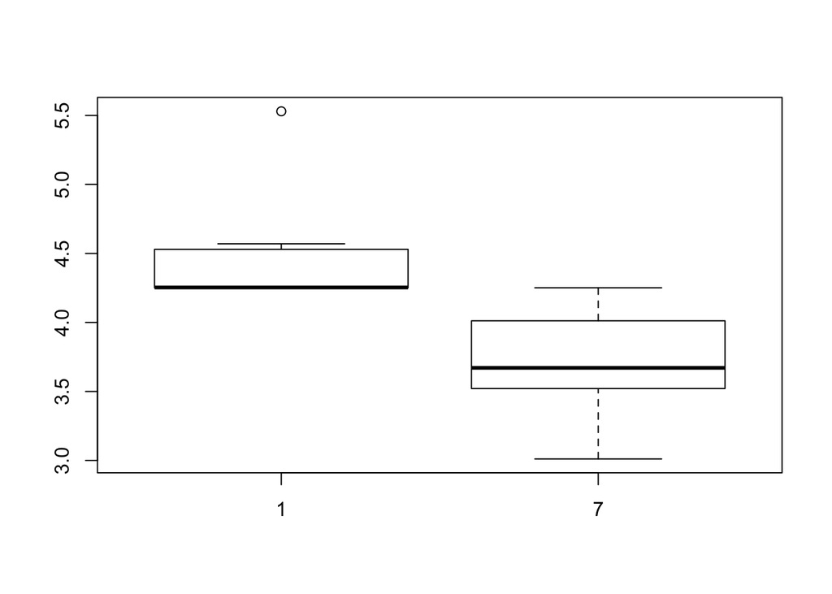

```r
boxplot(formula = pH ~ DurGROWTH,data = feeders)
```

```r
# maybe remove that one outlier and repeat shapiro-test, but population "day1"
# doesn't look very simetrical, so sampling could be repeated, eventually
# increasing sample n
```

- a.7) measurements in day 1 and day 7 were made always on the same feeder. What kind of strategy should be used for to compare these two days?

```r
# This can be viewed as a "before and after" situation, so it's paired data
```

- a.8) Perform the Bartlet test and the t.test/wilcoxon (depending on the normality tests results) to investigate if pH and OD_avg are different between the two days.